Name - Janhavee Kanoje

GH Number - GH1033705

Subject Code - M505A (Intro to AI and Machine Learning)

Professor's Name - Dr. Mohammad Madhavi

**Introduction**

Business Problem - A high student dropout rate affects the financial stability and reputation of the institution. Analysing this data will help the institution to get insights on the factors responsible for dropout rate and prevent it.

Data source for this model is: https://www.kaggle.com/datasets/thedevastator/higher-education-predictors-of-student-retention/data?select=dataset.csv

We aim to formulate this problem into a Machine Learning task.

**Import Required Packages**

```python
import pandas as pd
import numpy as np
import matplotlib.pyplot as plt
import seaborn as sns

from sklearn.model_selection import train_test_split
from sklearn.preprocessing import StandardScaler
from sklearn.decomposition import PCA
from sklearn import model_selection, compose, preprocessing, svm, metrics
from sklearn.compose import ColumnTransformer
from imblearn.over_sampling import SMOTE
from collections import Counter

from sklearn.svm import SVC
from sklearn.ensemble import RandomForestClassifier
from sklearn.tree import DecisionTreeClassifier
from sklearn.neighbors import KNeighborsClassifier

from sklearn.model_selection import GridSearchCV

from sklearn.metrics import accuracy_score, classification_report, confusion_matrix
```

Load and Split the dataset

The dataset has 34 features values and 1 target feature. We will split data into 80% train and 20% test set.

```python
df_1 = pd.read_csv("/content/dataset.csv")
print(df_1.shape)
df_1.head()
```

```
(4424, 35)
```

|  | Marital status | Application mode | Application order | Course | Daytime/evening attendance | Previous qualification | Nacionality | Mother's qualification | Father's qualification | Mother's occupation | Father's occupation | Displaced | Educational special needs | Debtor | Tuition fees up to date | Gender | Scholarship holder | Age at enrollment | International | Curricular units 1st sem (credited) | Curricular units 1st sem (enrolled) | Curricular units 1st sem (evaluations) | Curricular units 1st sem (approved) | Curricular units 1st sem (grade) | Curricular units 1st sem (without evaluations) | Curricular units 2nd sem (credited) | Curricular units 2nd sem (enrolled) | Curricular units 2nd sem (evaluations) | Curricular units 2nd sem (approved) | … |
| --- | --- | --- | --- | --- | --- | --- | --- | --- | --- | --- | --- | --- | --- | --- | --- | --- | --- | --- | --- | --- | --- | --- | --- | --- | --- | --- | --- | --- | --- | --- |
| 0 | 1 | 8 | 5 | 2 | 1 | 1 | 1 | 13 | 10 | 6 | 10 | 1 | 0 | 0 | 1 | 1 | 0 | 20 | 0 | 0 | 0 | 0 | 0 | 0.000000 | 0 | 0 | 0 | 0 | 0 | … |
| 1 | 1 | 6 | 1 | 11 | 1 | 1 | 1 | 1 | 3 | 4 | 4 | 1 | 0 | 0 | 0 | 1 | 0 | 19 | 0 | 0 | 6 | 6 | 6 | 14.000000 | 0 | 0 | 6 | 6 | 6 | … |
| 2 | 1 | 1 | 5 | 5 | 1 | 1 | 1 | 22 | 27 | 10 | 10 | 1 | 0 | 0 | 0 | 1 | 0 | 19 | 0 | 0 | 6 | 0 | 0 | 0.000000 | 0 | 0 | 6 | 0 | 0 | … |
| 3 | 1 | 8 | 2 | 15 | 1 | 1 | 1 | 23 | 27 | 6 | 4 | 1 | 0 | 0 | 1 | 0 | 0 | 20 | 0 | 0 | 6 | 8 | 6 | 13.428571 | 0 | 0 | 6 | 10 | 5 | … |
| 4 | 2 | 12 | 1 | 3 | 0 | 1 | 1 | 22 | 28 | 10 | 10 | 0 | 0 | 0 | 1 | 0 | 0 | 45 | 0 | 0 | 6 | 9 | 5 | 12.333333 | 0 | 0 | 6 | 6 | 6 | … |

```python
df_1_train, df_1_test, = model_selection.train_test_split(df_1, test_size=0.2, random_state=42)
print("df_1_size", df_1.shape)
print("df_1_train_size", df_1_train.shape)
print("df_1_test_size", df_1_test.shape)
```

```
df_1_size (4424, 35)
df_1_train_size (3539, 35)
df_1_test_size (885, 35)
```

**Data Exploration**

Here we checked for data type, null values and duplicated values, both seems to be null for this data.

```python
df_1_train.dtypes.value_counts()
```

|  | count |
| --- | --- |
| int64 | 29 |
| float64 | 5 |
| object | 1 |

**dtype:** int64

```python
df_1_train.isnull().values.any()
```

```
np.False_
```

```python
df_1.duplicated().sum()
```

```
np.int64(0)
```

**Data Preprocessing**

After analysing the features we dropped few of them which does not significantly contribute towards the target feature which is student's Graduate, Dropout or Enrolled status. Further we will process data to prepare it for modeling.

```python
x_1_train = df_1_train.drop(["Target", "Marital status", "Nacionality", "Gender", "Mother's occupation", "Father's occupation", "Educational special needs", "Father's qualification", "Mother's qualification"], axis=1)
y_1_train = df_1_train["Target"]
x_1_test = df_1_test.drop(["Target", "Marital status", "Nacionality", "Gender", "Mother's occupation", "Father's occupation", "Educational special needs", "Father's qualification", "Mother's qualification"], axis=1)
y_1_test = df_1_test["Target"]

print("x_1_train_size:", x_1_train.shape)
print("y_1_train_size:", y_1_train.shape)
print("x_1_test_size:", x_1_test.shape)
print("y_1_test_size:", y_1_test.shape)
```

```
x_1_train_size: (3539, 26)
y_1_train_size: (3539,)
x_1_test_size: (885, 26)
y_1_test_size: (885,)
```

As we can see the dataset is imbalanced, we will have to perform resampling, to give significant importance to minority features, and bring uniformity in the set, for a more unbiased model.

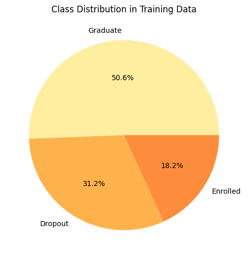

```python
target_class = y_1_train.value_counts()
plt.figure(figsize=(8, 6))
plt.pie(target_class, labels=target_class.index, autopct='%1.1f%%', colors=['#FFEDA0', '#FEB24C', '#FD8D3C'])
plt.title("Class Distribution in Training Data")
plt.show()
```

```python
print("Before sampling:", Counter(y_1_train))

sm = SMOTE(random_state=42)
x_resampled, y_resampled = sm.fit_resample(x_1_train, y_1_train)

print("After sampling:", Counter(y_resampled))
```

```
Before sampling: Counter({'Graduate': 1791, 'Dropout': 1105, 'Enrolled': 643})
After sampling: Counter({'Dropout': 1791, 'Enrolled': 1791, 'Graduate': 1791})
```

```python
num = x_resampled.select_dtypes(include =['int64', 'float64']).columns

preprocessor_org = ColumnTransformer(
    transformers=[
        ('nummerical', StandardScaler(), num)])

x_train_pre = preprocessor_org.fit_transform(x_resampled)
x_test_pre = preprocessor_org.transform(x_1_test)
```

**Model Training**

After resampling, we will check which algorithm gives highest accuracy score and do hyperparameter tuning to enhance the performance score.

```python
models = {
    "SVM": SVC(),
    "Random Forest": RandomForestClassifier(),
    "Decision Tree": DecisionTreeClassifier(),
    "KNN": KNeighborsClassifier()
}

for name, model in models.items():
    model.fit(x_train_pre, y_resampled)
    y_pred = model.predict(x_test_pre)

    print(f"\n{name} Performance Rate:")
    print("Accuracy:", accuracy_score(y_1_test, y_pred)*100)
```

```
SVM Performance Rate:
Accuracy: 73.78531073446327

Random Forest Performance Rate:
Accuracy: 74.12429378531074

Decision Tree Performance Rate:
Accuracy: 66.10169491525424

KNN Performance Rate:
Accuracy: 64.40677966101694
```

```python
param_grid = {
    "SVM": {"C": [0.1, 1, 10], "kernel": ["linear", "rbf"], "gamma": ["scale", "auto"]},
    "Random Forest": {"n_estimators": [50, 100, 200], "max_depth": [10, 20], "min_samples_split": [2, 5, 10]},
    "Decision Tree": {"max_depth": [5, 10, 15, 20], "criterion": ["gini", "entropy"], "splitter": ["best", "random"], "min_samples_split": [2,5,7,10]},
    "KNN": {"n_neighbors": [3, 7, 9], "weights": ["uniform", "distance"]},
}

best_models = {}
for name, model in models.items():
    grid = GridSearchCV(model, param_grid[name], cv=5, scoring="accuracy", n_jobs=-1)
    grid.fit(x_train_pre, y_resampled)
    best_models[name] = grid.best_estimator_

    print(f"\nSignificant parameters for {name}: {grid.best_params_}")
    print("Best accuracy:", grid.best_score_)
```

```
Significant parameters for SVM: {'C': 10, 'gamma': 'auto', 'kernel': 'rbf'}
Best accuracy: 0.803847559655277

Significant parameters for Random Forest: {'max_depth': 20, 'min_samples_split': 2, 'n_estimators': 100}
Best accuracy: 0.8367944220692045

Significant parameters for Decision Tree: {'criterion': 'gini', 'max_depth': 10, 'min_samples_split': 5, 'splitter': 'best'}
Best accuracy: 0.7597384262266684

Significant parameters for KNN: {'n_neighbors': 3, 'weights': 'distance'}
Best accuracy: 0.7815178207959811
```

As we can observe above, Random Forest gives maximum accuracy score of 83%, so we will train our model using Random Forest including its beat parameters and we got accuracy of 75%.

```python
classifier_name = "Random Forest"
best_models[classifier_name].fit(x_train_pre, y_resampled)

y_pred = best_models[classifier_name].predict(x_test_pre)
accuracy = accuracy_score(y_1_test, y_pred)
report = classification_report(y_1_test, y_pred)

print(f"Classifier: {classifier_name}")
print(f"Accuracy: {accuracy:.4f}")
print("Report:\n", report)
```

```
Classifier: Random Forest
Accuracy: 0.7514
Report:
               precision    recall  f1-score   support

     Dropout       0.85      0.71      0.77       316
    Enrolled       0.45      0.53      0.48       151
    Graduate       0.82      0.86      0.84       418

    accuracy                           0.75       885
   macro avg       0.70      0.70      0.70       885
weighted avg       0.76      0.75      0.76       885
```

**Data Visualization**

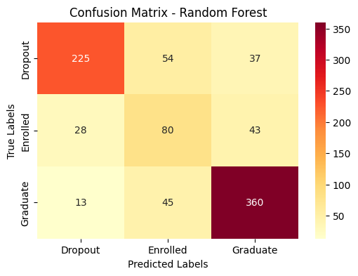

```python
conff_matrix = confusion_matrix(y_1_test, y_pred)

plt.figure(figsize=(6, 4))
sns.heatmap(conff_matrix, annot=True, fmt='d', cmap='YlOrRd', xticklabels=['Dropout', 'Enrolled', 'Graduate'], yticklabels=['Dropout', 'Enrolled', 'Graduate'])
plt.xlabel("Predicted Labels")
plt.ylabel("True Labels")
plt.title(f"Confusion Matrix - {classifier_name}")
plt.show()
```

Below are few visualizations which tells us about important features that effectively contribute to the target feature. From the below charts we can conclude that Curricular 1st sem(approved), Curricular 1st sem (grade), Curricular 2nd sem(approved), Curricular 2nd sem(grade), tution fees, age and course are major determining factors for target feature.

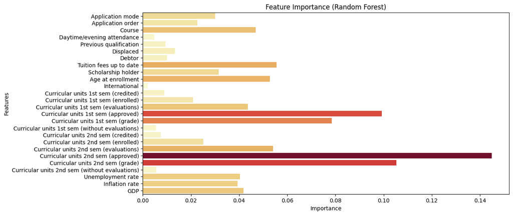

```python
if "Random Forest" in best_models:
    rf_model = best_models["Random Forest"]
    feature_importances = rf_model.feature_importances_
    feature_names = list(x_1_train.columns)

    plt.figure(figsize=(12, 6))
    sns.barplot(x=feature_importances, y=feature_names, hue=feature_importances, palette='YlOrRd', legend=False)
    plt.title("Feature Importance (Random Forest)")
    plt.xlabel("Importance")
    plt.ylabel("Features")
    plt.show()
```

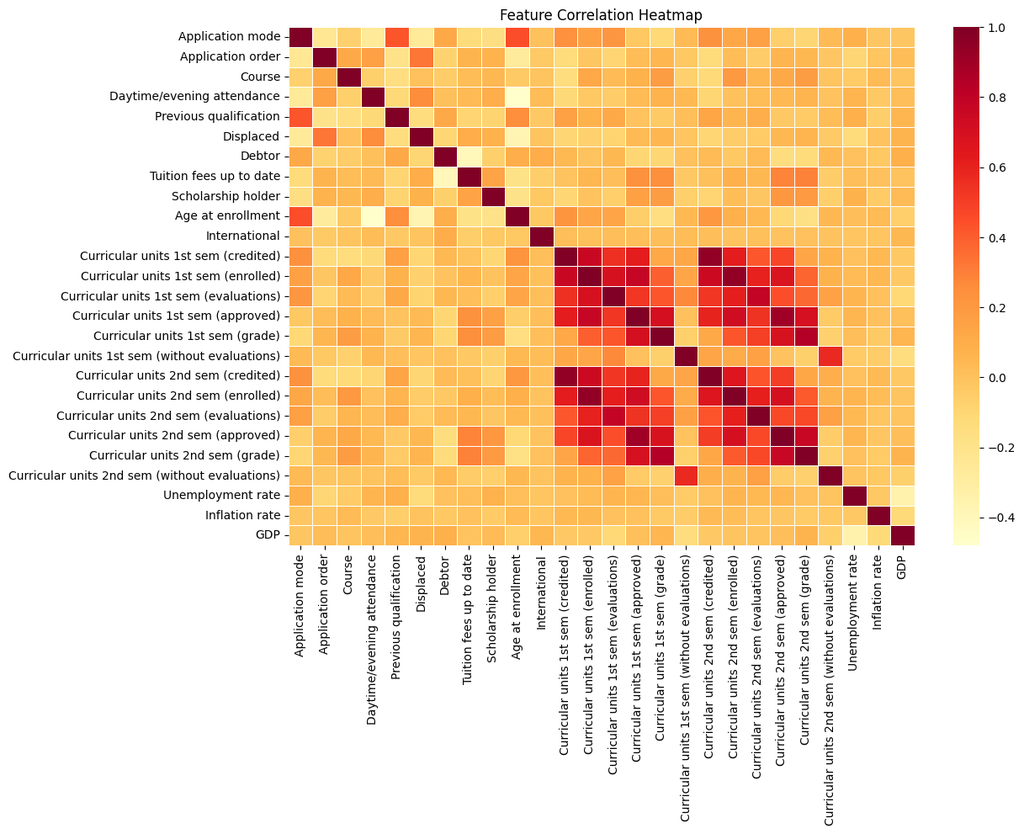

```python
plt.figure(figsize=(12, 8))
sns.heatmap(pd.DataFrame(x_1_train).corr(), annot=False, cmap='YlOrRd', linewidths=0.5)
plt.title("Feature Correlation Heatmap")
plt.show()
```

Both patterns are very similar showing a common peak around six units, that indicates specific course requirement or passing criterion, which means the minimum requirement to graduate is met around 6 units, whereas a high frequency of students with 0 authorised units, indicates dropouts. The frequency of students attaining higher course completion (15-20) are very few, which can probably be outliers (that are few students that excel extraordinarily)

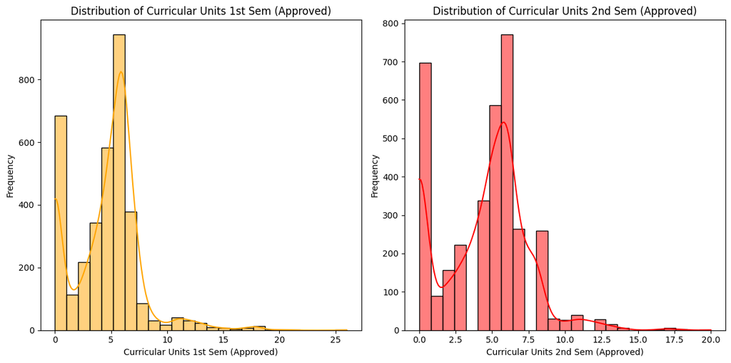

```python
plt.figure(figsize=(12, 6))

plt.subplot(1, 2, 1)
sns.histplot(x_1_train['Curricular units 1st sem (approved)'], kde=True, bins=25, color="orange")
plt.title("Distribution of Curricular Units 1st Sem (Approved)")
plt.xlabel("Curricular Units 1st Sem (Approved)")
plt.ylabel("Frequency")

plt.subplot(1, 2, 2)
sns.histplot(x_1_train['Curricular units 2nd sem (approved)'], kde=True, bins=25, color="red")
plt.title("Distribution of Curricular Units 2nd Sem (Approved)")
plt.xlabel("Curricular Units 2nd Sem (Approved)")
plt.ylabel("Frequency")
plt.tight_layout()
plt.show()
```

The chart discribes that dropouts have a wider course range as compared to graduates and enrolled. Institutions should create a more efficient curricular to reduce dropout rate and also provide some extra support for the students who are at higher risk to get dropped out.

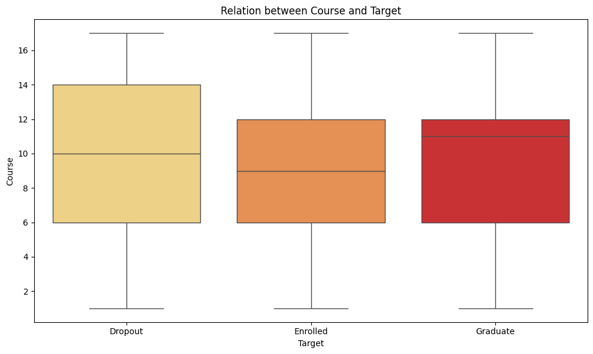

```python
plt.figure(figsize=(10, 6))
sns.boxplot(x=y_1_train, y=pd.DataFrame(x_1_train)['Course'], hue=y_1_train, palette='YlOrRd', legend=False)
plt.title("Relation between Course and Target")
plt.xlabel("Target")
plt.ylabel("Course")
plt.tight_layout()
plt.show()
```

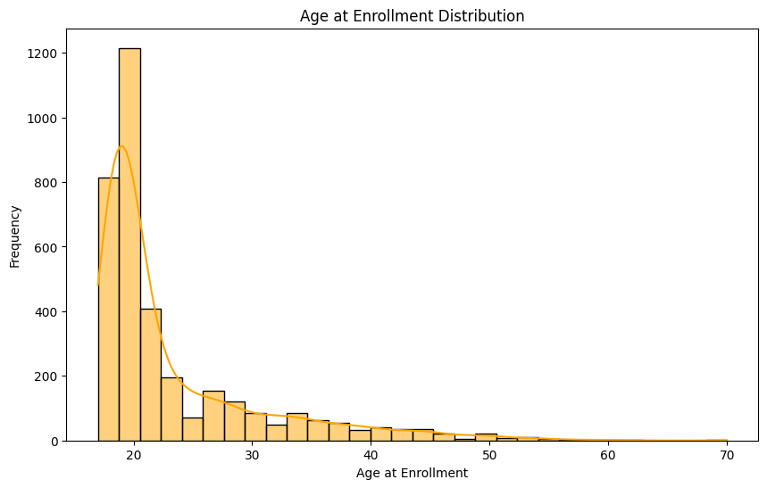

```python
plt.figure(figsize=(10, 6))
sns.histplot((x_1_train['Age at enrollment']), bins=30, kde=True, color='orange')
plt.title("Age at Enrollment Distribution")
plt.xlabel("Age at Enrollment")
plt.ylabel("Frequency")
plt.show()
```

Majority of students are non-debtors with highest graduate range, followed by dropout range. whereas, debtors have higher dropout range, with enrolled and graduate range going almost side-by-side. which implies financial stability plays crucial role in students completing their studies. To increase graduation rate, educational institutions should offer financial assistance.

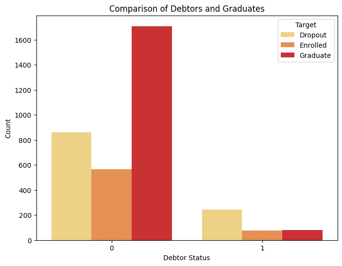

```python
plt.figure(figsize=(8, 6))
sns.countplot(x=x_1_train['Debtor'], hue=y_1_train, palette='YlOrRd')
plt.title("Comparison of Debtors and Graduates")
plt.xlabel("Debtor Status")
plt.ylabel("Count")
plt.legend(title="Target")
plt.show()
```

**Conclusion**

This machine learning pipeline provides insightful data to educational institutions to increase student performance and engagement. Debt, course, approved curriculars, age, etc,. being key factors for target determination, institutions should focus and seek for improvemnet in these areas by providing better student support and revised curricular.

There are certain limitations to this model and it is still missclassifying data at a noticable rate which can be fixed in future with better enhancements.

Overall, this model can be deployed as it may give a good-informed analysis and understanding of this data which can be useful to the institutions.